# HW2_DataMining

Yaniv Bronshtein

3/9/2021

**import libraries**

```r
library(tidyverse)
library(glmnet)
library(Matrix)
library(rsample)
library(ISLR)
library(pls)
```

## Question 3

*Bootstrap with Least squares, Ridge and Lasso* Let $\beta = (\beta_1,\beta_2, ..., \beta_p)$ and let x,y be random variables such that the entries of x are i.i.d standard normal variables (i.e, with mean zero and variance one) and $y = \beta^Tx + \epsilon$ where $\epsilon \sim N(0,1)$. (a). Simulate a dataset $(x_1, y_1), ...(x_n, y_n)$ as n i.i.d copies of the random variables x,y defined above, with $n=800$, $p = 200$, and $\beta_j = j^{-1}$.

```r
#Define n and p
p <- 200
n <- 800
#Construct x by create p copies of rnorm() which will generate n numbers. Each column represents a random variable x_i
x <- replicate(p, rnorm(n = n, mean = 0, sd = 1))
#Create the j vector
j = 1:p
#Beta is j inverted
beta <- j^-1
#Transform beta
beta_t <- beta %>% as.matrix()
#epsilon is a column vector nX1
epsilon <- rnorm(n = n, mean = 0, sd = 1) %>% as.matrix()
#Construct matrix y according to the formula in the question
y = x %*% beta_t + epsilon

#Create a data frame from y and x
df <- data.frame("y"= y, x)
```

2. The goal of this problem is to construct confidence intervals for $\beta_1$ using Bootstrap method.

**Specify a 95% confidence interval.** Use $\psi$ to avoid confusion with alpha in glmnet()

```r
psi = 0.05
```

**Generate the bootstraps to be used for all the models**

```r
set.seed(1)
samples <-df %>% bootstraps(1000)
```

(i). Construct confidence intervals for $\beta_1$ by boostrapping the data and applying Least Squares to the boostrapped data set. **Create a function to return the coefficients of the linear model**

```r
get_beta1_lm <- function(data){
  x_mat <- model.matrix(y~.,data)[,-1]
  y <- as.matrix(data['y'])
  lm_model <- lm(y ~ x_mat)
  beta_1_estim <- coef(lm_model)[2]
  return(beta_1_estim)
}
```

**Create a vector of 1000 bootstrap estimates of beta 1 for least square**

```r
estim_lm <- samples$splits %>%
  map(.,~as.data.frame(.)) %>%
  map(.,~get_beta1_lm(.)) %>%
  simplify()

estim_lm
```

[output not shown]

[output cut: 195 more lines]

[output not shown]

**Display the confidence interval for the bootstrap estimates by applying the quantile() function to get the lower and upper bounds and median() to get the estimate**

```r
lm_confint <- estim_lm %>%
  as.data.frame()
colnames(lm_confint)[1] = "estimate"
lm_confint <- lm_confint %>%
  summarise(conf.low = quantile(estimate, psi / 2),
            median = median(estimate),
            conf.high = quantile(estimate, 1 - psi / 2))
lm_confint
```

```
##    conf.low    median conf.high
## 1 0.9041645 0.9866946     1.069
```

2. Construct confidence intervals for $\beta_1$ by boostrapping the data and applying Ridge to the boostrapped data set. **Define x_mat_cv and y_cv to be used for cv.glmnet() for both ridge and lasso**

```r
x_mat_cv = model.matrix(y~.,df)[,-1]
y_cv = as.matrix(df['y'])
```

**Use cv.glmnet() to perform cross validation for ridge to extract the optimal(minimal) lambda to be used in glmnet()**

```r
best_lambda_ridge <- (cv.glmnet(x_mat_cv, y_cv, alpha = 0))$lambda.min
```

**Create a function to return the coefficients of the Ridge model**

```r
get_beta1_ridge = function(data){
  x_mat = model.matrix(y~.,data)[,-1]
  y = as.matrix(data['y'])
  ridge_model = glmnet(x_mat, y, alpha = 0, lambda = best_lambda_ridge)
  coef_ridge <- coef(ridge_model)
  beta_1_estim <- coef_ridge[2, 1]
  return(beta_1_estim)
}
```

**Create a vector of 1000 bootstrap estimates of beta 1 for ridge**

```r
estim_ridge <- samples$splits %>%
  map(.,~as.data.frame(.)) %>%
  map(.,~get_beta1_ridge(.)) %>%
  simplify()

estim_ridge
```

[output not shown]

[output cut: 128 more lines]

**Display the confidence interval for the bootstrap estimates by applying the quantile() function to get the lower and upper bounds and median() to get the estimate**

```r
ridge_confint <- estim_ridge %>%
  as.data.frame()
colnames(ridge_confint)[1] = "estimate"
ridge_confint <- ridge_confint %>%
  summarise(conf.low = quantile(estimate, psi / 2),
            median = median(estimate),
            conf.high = quantile(estimate, 1 - psi / 2))

ridge_confint
```

```
##    conf.low    median conf.high
## 1 0.7346169 0.7980479 0.8595639
```

(iii). Construct confidence intervals for $\beta_1$ by boostrapping the data and applying Lasso to the bootstrapped data set.

**Use cv.glmnet() to perform cross validation for lasso to extract the optimal(minimal) lambda to be used in glmnet()**

```r
best_lambda_lasso <- (cv.glmnet(x_mat_cv, y_cv, alpha = 1))$lambda.min
```

**Create a function to return the coefficients of the Lasso model**

```r
get_beta1_lasso = function(data){
  x_mat = model.matrix(y~.,data)[,-1]
  y = as.matrix(data['y'])
  lasso_model = glmnet(x_mat, y, alpha = 1, lambda = best_lambda_lasso)
  coef_lasso <- coef(lasso_model)
  beta_1_estim <- coef_lasso[2, 1]
  return(beta_1_estim)
}
```

**Create a vector of 1000 bootstrap estimates of beta 1 for lasso**

```r
estim_lasso <- samples$splits %>%
  map(.,~as.data.frame(.)) %>%
  map(.,~get_beta1_lasso(.)) %>%
  simplify()

estim_lasso
```

[output not shown]

[output cut: 128 more lines]

**Display the confidence interval for the bootstrap estimates by applying the quantile() function to get the lower and upper bounds and median() to get the estimate**

```r
lasso_confint <- estim_lasso %>%
  as.data.frame()
colnames(lasso_confint)[1] = "estimate"
lasso_confint <- lasso_confint %>%
  summarise(conf.low = quantile(estimate, psi / 2),
            median = median(estimate),
            conf.high = quantile(estimate, 1 - psi / 2))
lasso_confint
```

```
##    conf.low    median conf.high
## 1 0.8290113 0.8963068 0.9678655
```

## Problem 4(Question 9 in ISL Pg. 263 )

9.In this exercise, we will predict the number of applications received  
using the other variables in the College data set.

```r
data(College)
```

(a). Split the data set into a training set and a test set. set.seed(1)

```r
data(College)
set.seed(1)
smp_siz <- dim(College)[1] / 2

train <- sample(seq_len(nrow(College)),size = smp_siz)
test <- -train
data_train <- College[train,]
data_test <- College[test,]
```

(b). Fit a linear model using least squares on the training set, and report the test error obtained.

```r
lm_model <- lm(Apps ~ ., data = data_train)
lm_predict <- predict(lm_model, data_test)
lm_predict
```

[output not shown]

[output cut: 723 more lines]

[output not shown]

```r
test_error_least_square = mean((data_test[, 'Apps'] - lm_predict)^2)
test_error_least_square
```

```
## [1] 1135758
```

**For the next series of questions, we need our feature data to be in** **matrix form because glmnet() requires it. Thus we create a train and test** **matrix containing only feature values from our respectful train and test data**

```r
x_mat_train <- model.matrix(Apps ~ ., data = data_train)[, -1]
x_mat_test <- model.matrix(Apps ~ ., data = data_test)[, -1]
```

```r
lambda_min_ridge <- cv.glmnet(x_mat_train, data_train[, 'Apps'], alpha = 0)$lambda.min
lambda_min_ridge
```

```
## [1] 405.8404
```

**Fit a ridge_model using glmnet() with the optimal lambda** **Then, call predict() to get the prediction values to ultimately compute the test error**

```r
ridge_model <- glmnet(x_mat_train, data_train[, 'Apps'], lambda = lambda_min_ridge, alpha = 0)
ridge_predict <- predict(ridge_model, newx = x_mat_test, s = lambda_min_ridge)

test_error_ridge = mean((data_test[, 'Apps'] - ridge_predict)^2)
test_error_ridge
```

```
## [1] 976897.6
```

(d). Fit a lasso model on the training set, with $\lambda$ chosen by cross-validation. Report the test error obtained, along with the number of non-zero coefficient estimates.

**Extract the optimal lambda for lasso using cv.glmnet()**

```r
lambda_min_lasso <- cv.glmnet(x_mat_train, data_train[, 'Apps'], alpha = 1)$lambda.min
lambda_min_lasso
```

```
## [1] 1.97344
```

```r
lasso_model <- glmnet(x_mat_train, data_train[, 'Apps'], lambda = lambda_min_lasso, alpha = 1)
lasso_predict <- predict(lasso_model, newx = x_mat_test, s = lambda_min_lasso)

test_error_lasso = mean((data_test[, 'Apps'] - lasso_predict)^2)
test_error_lasso
```

```
## [1] 1116402
```

**Extract the coefficients from the lasso model**

```r
coef_lasso <- coef(lasso_model)
coef_lasso
```

```
## 18 x 1 sparse Matrix of class "dgCMatrix"
##                        s0
## (Intercept) -763.46736132
## PrivateYes  -313.76789130
## Accept         1.76295802
## Enroll        -1.32011619
## Top10perc     64.98040139
## Top25perc    -20.93406827
## F.Undergrad    0.07157355
## P.Undergrad    0.01197052
## Outstate      -0.10493165
## Room.Board     0.20915417
## Books          0.29265420
## Personal       0.00351509
## PhD          -14.48803558
## Terminal       5.33334391
## S.F.Ratio     21.67584609
## perc.alumni    0.51564913
## Expend         0.04812700
## Grad.Rate      7.01799292
```

**Filter out the coefficients equal to zero. Note this process removes the names**

```r
coef_lasso_vec <- coef_lasso %>% as.vector()
coef_lasso_vec
```

```
##  [1] -763.46736132 -313.76789130    1.76295802   -1.32011619   64.98040139
##  [6]  -20.93406827    0.07157355    0.01197052   -0.10493165    0.20915417
## [11]    0.29265420    0.00351509  -14.48803558    5.33334391   21.67584609
## [16]    0.51564913    0.04812700    7.01799292
```

```r
coef_lasso_non_zero <- subset(coef_lasso_vec, !(coef_lasso_vec %in% 0.0))
coef_lasso_non_zero
```

```
##  [1] -763.46736132 -313.76789130    1.76295802   -1.32011619   64.98040139
##  [6]  -20.93406827    0.07157355    0.01197052   -0.10493165    0.20915417
## [11]    0.29265420    0.00351509  -14.48803558    5.33334391   21.67584609
## [16]    0.51564913    0.04812700    7.01799292
```

(e). Fit a PCR model on the training set, with M chosen by cross validation. Report the test error obtained, along with the value of M selected by cross-validation.

**Fit a PCR model using Cross Validation**

```r
set.seed(1)
pcr_model <- pcr(Apps ~., data = data_train, scale = TRUE,
                 validation = "CV")

summary(pcr_model)
```

```
## Data:    X dimension: 388 17
##  Y dimension: 388 1
## Fit method: svdpc
## Number of components considered: 17
##
## VALIDATION: RMSEP
## Cross-validated using 10 random segments.
##        (Intercept)  1 comps  2 comps  3 comps  4 comps  5 comps  6 comps
## CV            4288     4006     2373     2372     2069     1961     1919
## adjCV         4288     4007     2368     2369     1999     1948     1911
##        7 comps  8 comps  9 comps  10 comps  11 comps  12 comps  13 comps
## CV        1919     1921     1876      1832      1832      1836      1837
## adjCV     1912     1915     1868      1821      1823      1827      1827
##        14 comps  15 comps  16 comps  17 comps
## CV         1853      1759      1341      1270
## adjCV      1850      1733      1326      1257
##
## TRAINING: % variance explained
##       1 comps  2 comps  3 comps  4 comps  5 comps  6 comps  7 comps  8 comps
## X       32.20    57.78    65.31    70.99    76.37    81.27     84.8    87.85
## Apps    13.44    70.93    71.07    79.87    81.15    82.25     82.3    82.33
##       9 comps  10 comps  11 comps  12 comps  13 comps  14 comps  15 comps
## X       90.62     92.91     94.98     96.74     97.79     98.72     99.42
## Apps    83.38     84.76     84.80     84.84     85.11     85.14     90.55
##       16 comps  17 comps
## X        99.88    100.00
## Apps     93.42     93.89
```

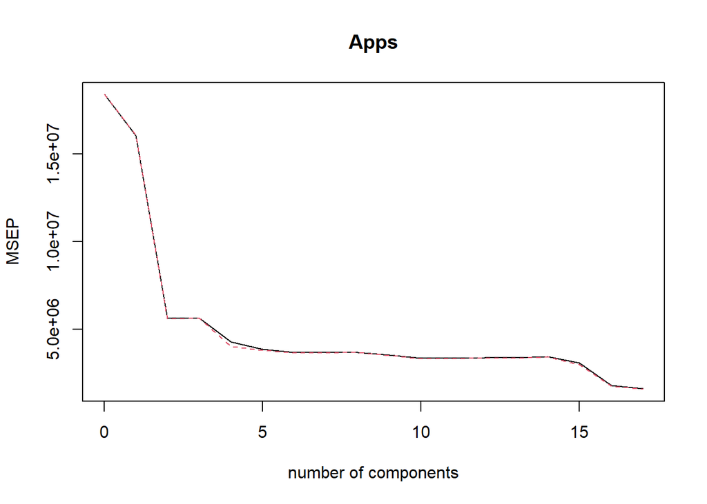

```r
validationplot(pcr_model, val.type = "MSEP")
```

**Report the test error obtained for pcr**

```r
pcr_predict <- predict(pcr_model, x_mat_test, ncomp = 6)
test_error_pcr <- mean((data_test[, 'Apps'] - pcr_predict)^2)
test_error_pcr
```

```
## [1] 1966028
```

(f). Fit a PLS model on the training set, with M chosen by cross-validation. Report the test error obtained, along with the value of M selected by cross-validation.

**Fit a PLS model using Cross Validation**

```r
set.seed(1)
pls_model <- plsr(Apps ~ ., data = data_train, scale = TRUE, validation = "CV")

summary(pls_model)
```

```
## Data:    X dimension: 388 17
##  Y dimension: 388 1
## Fit method: kernelpls
## Number of components considered: 17
##
## VALIDATION: RMSEP
## Cross-validated using 10 random segments.
##        (Intercept)  1 comps  2 comps  3 comps  4 comps  5 comps  6 comps
## CV            4288     2217     2019     1761     1630     1533     1347
## adjCV         4288     2211     2012     1749     1605     1510     1331
##        7 comps  8 comps  9 comps  10 comps  11 comps  12 comps  13 comps
## CV        1309     1303     1286      1283      1283      1277      1271
## adjCV     1296     1289     1273      1270      1270      1264      1258
##        14 comps  15 comps  16 comps  17 comps
## CV         1270      1270      1270      1270
## adjCV      1258      1257      1257      1257
##
## TRAINING: % variance explained
##       1 comps  2 comps  3 comps  4 comps  5 comps  6 comps  7 comps  8 comps
## X       27.21    50.73    63.06    65.52    70.20    74.20    78.62    80.81
## Apps    75.39    81.24    86.97    91.14    92.62    93.43    93.56    93.68
##       9 comps  10 comps  11 comps  12 comps  13 comps  14 comps  15 comps
## X       83.29     87.17     89.15     91.37     92.58     94.42     96.98
## Apps    93.76     93.79     93.83     93.86     93.88     93.89     93.89
##       16 comps  17 comps
## X        98.78    100.00
## Apps     93.89     93.89
```

**Generate a validation plot to determine the optimal value of M for pls** **Based on the plot, M is either 6 or 7. We shall go with 6**

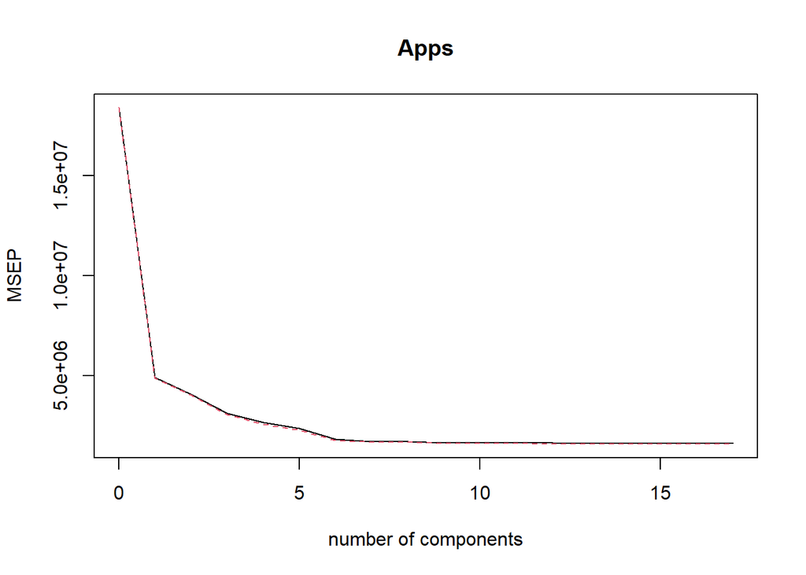

```r
validationplot(pls_model, val.type = "MSEP")
```

```r
pls_predict <- predict(pls_model, x_mat_test, ncomp = 6)
test_error_pls <- mean((data_test[, 'Apps'] - pls_predict)^2)
test_error_pls
```

```
## [1] 1066991
```

(g). Comment on the results obtained. How accurately can we predict the number of college applications received? Is there much difference among the test errors resulting from these five approaches?

```r
lm_test_r2 <- 1 - test_error_least_square / mean((data_test[, 'Apps'] - mean(data_test[, 'Apps']))^2)
ridge_test_r2 <- 1 - test_error_ridge / mean((data_test[, 'Apps'] - mean(data_test[, 'Apps']))^2)
lasso_test_r2 <- 1 - test_error_lasso / mean((data_test[, 'Apps'] - mean(data_test[, 'Apps']))^2)
pcr_test_r2 <- 1 - test_error_pcr / mean((data_test[, 'Apps'] - mean(data_test[, 'Apps']))^2)
pls_test_r2 <- 1 - test_error_pls / mean((data_test[, 'Apps'] - mean(data_test[, 'Apps']))^2)
```

**OLS**

```r
cat("Test Error:", test_error_least_square, "\n")
```

```
## Test Error: 1135758
```

```r
cat("R squared:", lm_test_r2)
```

```
## R squared: 0.9015413
```

**Ridge**

```r
cat("Test Error:", test_error_ridge, "\n")
```

```
## Test Error: 976897.6
```

```r
cat("R squared:", ridge_test_r2)
```

```
## R squared: 0.9153129
```

**Lasso**

```r
cat("Test Error:", test_error_lasso, "\n")
```

```
## Test Error: 1116402
```

```r
cat("R squared:", lasso_test_r2)
```

```
## R squared: 0.9032193
```

**PCR**

```r
cat("Test Error:", test_error_pcr, "\n")
```

```
## Test Error: 1966028
```

```r
cat("R squared:", pcr_test_r2)
```

```
## R squared: 0.8295654
```

**PLS**

```r
cat("Test Error:", test_error_pls, "\n")
```

```
## Test Error: 1066991
```

```r
cat("R squared:", pls_test_r2)
```

```
## R squared: 0.9075028
```